# Free Response

1. We have the Bell State $\frac{1}{\sqrt{2}}\big(|10\rangle+|01\rangle\big)$. We see that on the second qubit, the rightmost number of each ket, half of them are the state $|1\rangle$. More specifically, you'd need to measure the state $|01\rangle$. So, $Pr(|01\rangle) = |\frac{1}{\sqrt{2}}|^2 = \frac{1}{2}$.
1. Now, we want to measure $|0\rangle$ on the first qubit in the same Bell State. Again, we can find the state that has $|0\rangle$ as its first qubit is the state $|01\rangle$. Following the above calculation, we know that $Pr(|01\rangle)=\frac{1}{2}$.
1. The CNOT Gate works with two input qubits. The first input is the control qubit and the second input is the target qubit. If the control qubit is $|0\rangle$, then nothing happens to the target qubit. If the control qubit is $|1\rangle$, then the target qubit gets the $X$ gate applied to it, flipping the qubit. Note there are four possible two-qubit states: $|00\rangle, |01\rangle, |10\rangle, |11\rangle$.

If we do not want to change the target qubit, meaning that the first qubit is $|0\rangle$, that means there's only two possible input states to meet this criteria: $|00\rangle, |01\rangle$.

1. $$|\psi_i\rangle=|\psi_1\rangle|\psi_2\rangle=(\alpha_1|0\rangle+\beta_1|1\rangle)(\alpha_2|0\rangle+\beta_2|1\rangle)\\ |\psi_f\rangle=|\psi_2\rangle|\psi_1\rangle=(\alpha_2|0\rangle+\beta_2|1\rangle)(\alpha_1|0\rangle+\beta_1|1\rangle)$$
- You can foil these two states out to get the following:

$|\psi_i\rangle = \begin{bmatrix} a_1a_2 \\ a_1b_2 \\ b_1a_2 \\ b_1b_2 \end{bmatrix}, |\psi_f\rangle = \begin{bmatrix} a_1a_2 \\ a_2b_1 \\ b_2a_1 \\ b_1b_2 \end{bmatrix}$

You can see that the first and last values are the same for both vectors, but the middle two values are flipped.

- In order to interchange these two vectors, we will need to construct a gate that can flip the middle two entires. In matrix form, we can take the 4x4 $I = \begin{bmatrix} 1 \ 0 \ 0 \ 0 \\ 0 \ 1 \ 0 \ 0 \\ 0 \ 0 \ 1 \ 0 \\ 0 \ 0 \ 0 \ 1 \end{bmatrix}$ and flipping the middle two rows. This gives the matrix: $\begin{bmatrix} 1 \ 0 \ 0 \ 0 \\ 0 \ 0 \ 1 \ 0 \\ 0 \ 1 \ 0 \ 0 \\ 0 \ 0 \ 0 \ 1 \end{bmatrix}$

# Challenge

1. Here, want want to implement the other three Bell States: $\frac{1}{\sqrt{2}}(|00\rangle-|11\rangle)$, $\frac{1}{\sqrt{2}}(|01\rangle+|10\rangle)$, and $\frac{1}{\sqrt{2}}(|01\rangle-|10\rangle)$
- The first on the list can be achieved by placing an $X$ gate before the $H$ gate on the first qubit, making a $|-\rangle=\frac{1}{\sqrt{2}}(|0\rangle-|1\rangle)$ on each of the two qubits. You'll see upon measurement that both states have probability $50\%$ as expected. Note that the phase does not show up in measurement here, but it will show up in the actual state.

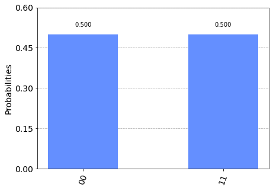

```python
from qiskit import QuantumCircuit, assemble, Aer
from qiskit.visualization import plot_histogram, plot_bloch_vector
from math import sqrt, pi

#simulator for checking qubit states later on
simulator = Aer.get_backend('statevector_simulator')


#circuit for second bell state
bell_state_2 = QuantumCircuit(2)


#write your code here for bell_state_2:
bell_state_2.x(0)
bell_state_2.h(0)
bell_state_2.cx(0,1)



#run check for bell_state_2
qobj2 = assemble(bell_state_2)
result2 = simulator.run(qobj2).result()
counts2 = result2.get_counts()
plot_histogram(counts2)
```

- The second on the list can be achieved by adding a $X$ gate to the second qubit, where it will flip the second qubit, but not interact with the $H$ gate causing a sign flip.

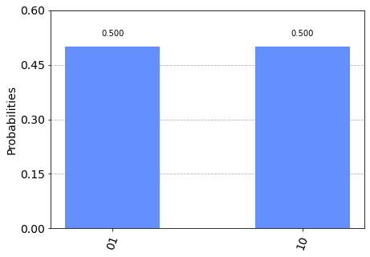

```python
from qiskit import QuantumCircuit, assemble, Aer
from qiskit.visualization import plot_histogram, plot_bloch_vector
from math import sqrt, pi

#simulator for checking qubit states later on
simulator = Aer.get_backend('statevector_simulator')

#circuit for third bell state
bell_state_3 = QuantumCircuit(2)

#write your code here for bell_state_3:
bell_state_3.x(1)
bell_state_3.h(0)
bell_state_3.cx(0,1)

#run check for bell_state_3
qobj3 = assemble(bell_state_3)
result3 = simulator.run(qobj3).result()
counts3 = result3.get_counts()
plot_histogram(counts3)
```

- The final state we want is going to need a combination of the prior two. We need a bit flip on the second qubit, and phase flip on the first qubit. So, combining those will place a $X$ gate on the first and second qubit prior to the $H$ and $CNOT$. Again, the phase will not show up in measurement, but it is there in the state.

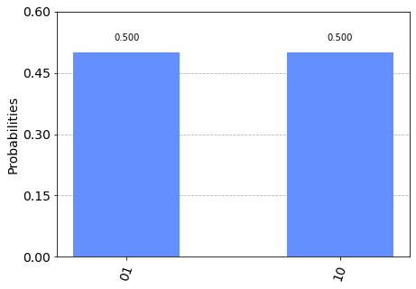

```python
from qiskit import QuantumCircuit, assemble, Aer
from qiskit.visualization import plot_histogram, plot_bloch_vector
from math import sqrt, pi

#simulator for checking qubit states later on
simulator = Aer.get_backend('statevector_simulator')

#circuit for fourth bell state
bell_state_4 = QuantumCircuit(2)

#write your code here for bell_state_4:
bell_state_4.x(0)
bell_state_4.x(1)
bell_state_4.h(0)
bell_state_4.cx(0,1)

#run check for bell_state_4
qobj4 = assemble(bell_state_4)
result4 = simulator.run(qobj4).result()
counts4 = result4.get_counts()
plot_histogram(counts4)
```

1. Note the two new states we learned: $\left|+\right> =\frac{1}{\sqrt{2}}\left( \left| 0 \right> + \left| 1 \right> \right)$ , $\left|-\right> =\frac{1}{\sqrt{2}}\left( \left| 0 \right> + \left| 1 \right> \right)$. To achieve the $|+\rangle$ in qiskit, we apply a $H$ to the $|0\rangle$ state. To achieve a $|-\rangle$, we apply a $H$ to the $|1\rangle$ state, or $XH$ to the $|0\rangle$ state.
- $\left|+\right>\left|0\right>=\tfrac{1}{\sqrt{2}} \left| 00 \right> + \tfrac{1}{\sqrt{2}}\left| 10 \right> $

```python
from qiskit import *

circ = QuantumCircuit(2,2)

#state preparation
circ.h(0)

#execute the circuit to get measurement probabilities
circ.measure([0,1],[1,0])
backend_sim = Aer.get_backend('qasm_simulator')
sim = execute(circ, backend_sim, shots=1024)
counts = sim.result().get_counts(circ)
print(counts)
```

```
{'00': 525, '10': 499}
```

- $\left|0\right>\left|-\right>=\tfrac{1}{\sqrt{2}} \left| 00 \right> - \tfrac{1}{\sqrt{2}}\left| 01 \right> $

```python
from qiskit import *

circ = QuantumCircuit(2,2)

#state preparation
circ.x(1)
circ.h(1)

#execute the circuit to get measurement probabilities
circ.measure([0,1],[1,0])
backend_sim = Aer.get_backend('qasm_simulator')
sim = execute(circ, backend_sim, shots=1024)
counts = sim.result().get_counts(circ)
print(counts)
```

```
{'01': 519, '00': 505}
```

- $\left|1\right>\left|+\right>=\tfrac{1}{\sqrt{2}} \left| 10 \right> + \tfrac{1}{\sqrt{2}}\left| 11 \right>$

```python
from qiskit import *

circ = QuantumCircuit(2,2)

#state preparation
circ.x(0)
circ.h(1)

#execute the circuit to get measurement probabilities
circ.measure([0,1],[1,0])
backend_sim = Aer.get_backend('qasm_simulator')
sim = execute(circ, backend_sim, shots=1024)
counts = sim.result().get_counts(circ)
print(counts)
```

```
{'11': 521, '10': 503}
```

- $\left|+\right>\left|+\right>=\tfrac12 \left| 00 \right> + \tfrac12\left| 01 \right> + \tfrac12 \left| 10 \right> + \tfrac12\left| 11 \right>$

```python
from qiskit import *

circ = QuantumCircuit(2,2)

#state preparation
circ.h(0)
circ.h(1)

#execute the circuit to get measurement probabilities
circ.measure([0,1],[1,0])
backend_sim = Aer.get_backend('qasm_simulator')
sim = execute(circ, backend_sim, shots=1024)
counts = sim.result().get_counts(circ)
print(counts)
```

```
{'01': 238, '11': 282, '10': 253, '00': 251}
```

- $\left|+\right>\left|-\right>=\tfrac12 \left| 00 \right> - \tfrac12\left| 01 \right> + \tfrac12 \left| 10 \right> - \tfrac12\left| 11 \right>$

```python
from qiskit import *

circ = QuantumCircuit(2,2)

#state preparation
circ.h(0)
circ.x(1)
circ.h(1)

#execute the circuit to get measurement probabilities
circ.measure([0,1],[1,0])
backend_sim = Aer.get_backend('qasm_simulator')
sim = execute(circ, backend_sim, shots=1024)
counts = sim.result().get_counts(circ)
print(counts)
```

```
{'01': 246, '11': 278, '10': 238, '00': 262}
```

1. The circuit depicted in the image flips the control and target qubits of the $CNOT$ gate, essentially turning it upside. Note that in qiskit, you can turn a $CNOT$ upside down with needing the $H$ gates, but for other softwares, that might not be the case. This circuit will have the following inputs and outputs:
- $|00\rangle \rightarrow |00\rangle$
- $|01\rangle \rightarrow |11\rangle$
- $|10\rangle \rightarrow |10\rangle$
- $|11\rangle \rightarrow |01\rangle$

It can be implemented as follows:

```python
from qiskit import QuantumCircuit, Aer, execute
from fractions import Fraction
circ=QuantumCircuit(2,2)

circ = QuantumCircuit(2)

#Upside CNOT
circ.h(0)
circ.h(1)
circ.cx(0,1)
circ.h(0)
circ.h(1)

circ.draw()
```

```
     ┌───┐     ┌───┐
q_0: ┤ H ├──■──┤ H ├
     ├───┤┌─┴─┐├───┤
q_1: ┤ H ├┤ X ├┤ H ├
     └───┘└───┘└───┘
```